# 3'-UTR Calling in *B. subtilis*

Date: 19 June 2022

Author: Julian Stanley

Purpose: Use Rend-seq data to determine the location and sequences of putative 3'-UTRs in WT *Bacillus subtilis* in exponential growth.

Tools: I'll use [`rendseq`](https://github.com/miraep8/rendseq) from Mirae on Rend-seq data that Jean produced. I'll cross-reference that with predicted terminators from [Jean's prediction pipeline](https://github.com/jblalanne/intrinsic_trx_terminator_identifier). I'll then use igv-notebook to visualize results.

## Assumptions

Below is a running list of assumptions I'm making in this analysis:

#### Threshold Assumption

Once Z-scores are computed, a Z-score threshold is chosen automatically to seperate "peak" Z-scores from "non-peak" Z-scores. This threshold is based on very rough statistics that assume a normal distribution of Z-scores, and then choose a threshold at the point where the sum of Z-scores exceeds the expected sum by a factor of 10,000. See [this point in the source code](https://github.com/miraep8/rendseq/blob/210dc1aaaf60ee5c8147b7235396dc1c258d3ebc/rendseq/make_peaks.py#L166-L176) for details.

#### Operon Assumption

If a gene's annotated stop codon is within 100bp of another gene's annotated start codon, I'll consider those genes to be operonic. When this is the case, I'll consider the *adjusted stop* of the upstream gene to be the same as the stop of it's most-downstream operon.

## Peak calling

First, we'll use Mirae's rendseq package to assign z_scores to each point in the rend-seq data and set a z-score threshold to classify peaks.

We're using rend-seq 170810, from WT B. subtilis in LB, with 1:1 cold methanol and extracted with RNeasy.

We'll re-run the exact same analysis with the samples extracted from RNA Snap and compare results

```python
from rendseq.file_funcs import open_wig
from rendseq.zscores import z_scores
from rendseq.make_peaks import hmm_peaks, thresh_peaks
from matplotlib import pyplot as plt
from rendseq.file_funcs import write_wig
from os import path
%matplotlib inline
```

RNeasy samples:

```python
path.basename(wig_paths['3f']).replace('.wig', '_peaks.wig')
```

```
'170810Li_168_rend_tot_rneasy_3_f_peaks.wig'
```

```
Working with reads: 3f from ./wigs/170810Li_168_rend_tot_rneasy_3_f.wig
Working with reads: 3r from ./wigs/170810Li_168_rend_tot_rneasy_3_r.wig
Working with reads: 5f from ./wigs/170810Li_168_rend_tot_rneasy_5_f.wig
Working with reads: 5r from ./wigs/170810Li_168_rend_tot_rneasy_5_r.wig
```

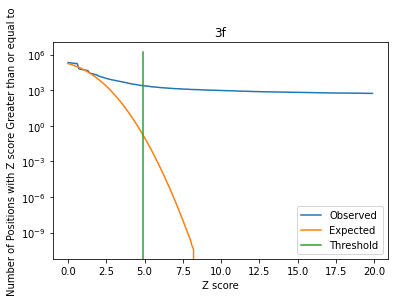

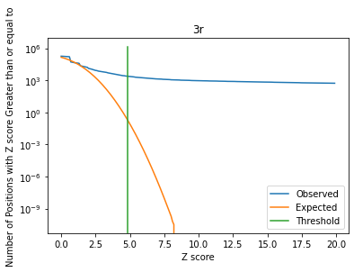

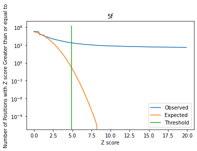

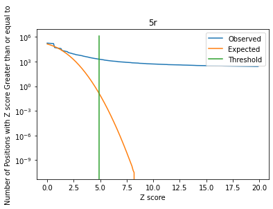

```python
wig_paths = {'3f': './wigs/170810Li_168_rend_tot_rneasy_3_f.wig',
             '3r': './wigs/170810Li_168_rend_tot_rneasy_3_r.wig',
             '5f': './wigs/170810Li_168_rend_tot_rneasy_5_f.wig',
             '5r': './wigs/170810Li_168_rend_tot_rneasy_5_r.wig'}

scores_peaks = {'3f': {},
                '3r' : {},
                '5f': {},
                '5r': {}}

for read_type, wig_path in wig_paths.items():
    reads, chrom = open_wig(wig_path)
    print(f"Working with reads: {read_type} from {wig_path}")

    plt.figure()
    plt.title(f"{read_type}")

    z_score_transformed_data = z_scores(reads)
    thresh_peaks_found = thresh_peaks(z_score_transformed_data)

    scores_peaks[read_type]['z_scores'] = z_score_transformed_data
    scores_peaks[read_type]['peaks'] = thresh_peaks_found

    # Write wigs to file
    peaks_fname = path.basename(wig_path).replace('.wig', '_peaks.wig')
    write_wig(thresh_peaks_found, f'wigs_peaks/{peaks_fname}', chrom)
```

RNA Snap samples:

```
Working with reads: 3f from ./wigs/170810Li_168_rend_tot_snap_3_f.wig
Working with reads: 3r from ./wigs/170810Li_168_rend_tot_snap_3_r.wig
Working with reads: 5f from ./wigs/170810Li_168_rend_tot_snap_5_f.wig
Working with reads: 5r from ./wigs/170810Li_168_rend_tot_snap_5_r.wig
```

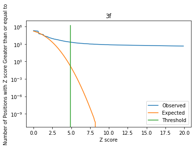

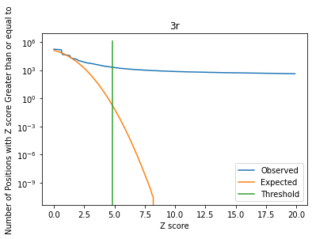

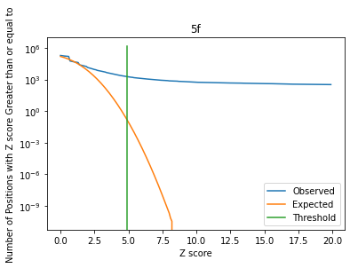

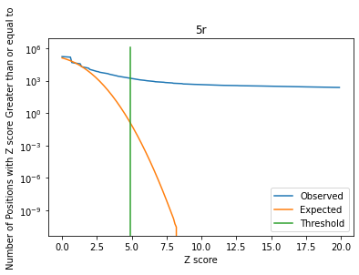

```python
wig_paths_snap = {'3f': './wigs/170810Li_168_rend_tot_snap_3_f.wig',
             '3r': './wigs/170810Li_168_rend_tot_snap_3_r.wig',
             '5f': './wigs/170810Li_168_rend_tot_snap_5_f.wig',
             '5r': './wigs/170810Li_168_rend_tot_snap_5_r.wig'}

scores_peaks_snap = {'3f': {},
                '3r' : {},
                '5f': {},
                '5r': {}}

for read_type, wig_path in wig_paths_snap.items():
    reads, chrom = open_wig(wig_path)
    print(f"Working with reads: {read_type} from {wig_path}")

    plt.figure()
    plt.title(f"{read_type}")

    z_score_transformed_data = z_scores(reads)
    thresh_peaks_found = thresh_peaks(z_score_transformed_data)

    scores_peaks_snap[read_type]['z_scores'] = z_score_transformed_data
    scores_peaks_snap[read_type]['peaks'] = thresh_peaks_found

    # Write wigs to file
    peaks_fname = path.basename(wig_path).replace('.wig', '_peaks.wig')
    write_wig(thresh_peaks_found, f'wigs_peaks/{peaks_fname}', chrom)
```

# Searching for peaks in annotations

```python
import pandas as pd
```

### Make a list of all peaks for easy reference

```python
def list_peaks(peaks_list):
    return_peaks = []
    for peak_arr in peaks_list:
        if peak_arr[1] == 1:
            return_peaks.append(peak_arr[0])
    return return_peaks



forward_3p_peaks = list_peaks(scores_peaks['3f']['peaks'])
reverse_3p_peaks = list_peaks(scores_peaks['3r']['peaks'])
```

### Make dictionary of gene ends

```python
genes = pd.read_table("annotations/CDS_168.mochiview_v13.txt")
```

```python
genes_reverse = genes[genes.STRAND == '-']
genes_forward = genes[genes.STRAND == '+']
```

```python
genes_forward_simple = genes_forward[["GENE_NAME", "END"]].set_index("GENE_NAME")
gene_to_end_fwd = genes_forward_simple.to_dict()['END']
```

```python
# For the reverse strand, transcription ends are given by 'START' location
genes_reverse_simple = genes_reverse[["GENE_NAME", "START"]].set_index("GENE_NAME")
gene_to_end_rev = genes_reverse_simple.to_dict()['START']
```

```python
genes_reverse
```

|  | SEQ_NAME | START | END | STRAND | FEATURE_NAME | GENE_NAME | ALIASES | DESCRIPTION | TXN_START | TXN_END | CDS_START | CDS_END | EXON_COUNT | EXON_STARTS | EXON_ENDS | ISOFORM_NAME | IS_PRIMARY |
| --- | --- | --- | --- | --- | --- | --- | --- | --- | --- | --- | --- | --- | --- | --- | --- | --- | --- |
| 0 | NC_000964.3 | 24 | 297 | - | BSU_none_49 | S2 | ncRNA | NaN | 24 | 297 | 24 | 297 | 1 | 24 | 297 | Y | NaN |
| 1 | NC_000964.3 | 299 | 1067 | - | BSU_none_50 | S4 | ncRNA | NaN | 299 | 1067 | 299 | 1067 | 1 | 299 | 1067 | Y | NaN |
| 14 | NC_000964.3 | 14847 | 15794 | - | BSU00080 | yaaC | gene | NaN | 14847 | 15794 | 14847 | 15794 | 1 | 14847 | 15794 | Y | NaN |
| 16 | NC_000964.3 | 17238 | 17833 | - | BSU_none_51 | S9 | ncRNA | NaN | 17238 | 17833 | 17238 | 17833 | 1 | 17238 | 17833 | Y | NaN |
| 19 | NC_000964.3 | 19194 | 19923 | - | BSU_none_52 | S13 | ncRNA | NaN | 19194 | 19923 | 19194 | 19923 | 1 | 19194 | 19923 | Y | NaN |
| ... | ... | ... | ... | ... | ... | ... | ... | ... | ... | ... | ... | ... | ... | ... | ... | ... | ... |
| 4486 | NC_000964.3 | 4211510 | 4212889 | - | BSU41020 | trmE | gene | NaN | 4211510 | 4212889 | 4211510 | 4212889 | 1 | 4211510 | 4212889 | Y | NaN |
| 4488 | NC_000964.3 | 4213200 | 4213826 | - | BSU41030 | jag | gene | NaN | 4213200 | 4213826 | 4213200 | 4213826 | 1 | 4213200 | 4213826 | Y | NaN |
| 4489 | NC_000964.3 | 4213823 | 4214608 | - | BSU41040 | spoIIIJ | gene | NaN | 4213823 | 4214608 | 4213823 | 4214608 | 1 | 4213823 | 4214608 | Y | NaN |
| 4490 | NC_000964.3 | 4214753 | 4215103 | - | BSU41050 | rnpA | gene | NaN | 4214753 | 4215103 | 4214753 | 4215103 | 1 | 4214753 | 4215103 | Y | NaN |
| 4491 | NC_000964.3 | 4215255 | 4215389 | - | BSU41060 | rpmH | gene | NaN | 4215255 | 4215389 | 4215255 | 4215389 | 1 | 4215255 | 4215389 | Y | NaN |

2323 rows × 17 columns

## Data validation

```python
import igv_notebook
igv_notebook.init()
```

```python
b = igv_notebook.Browser(
    {
        "reference": {
            'id': "168",
            "fastaURL": "annotations/B_subtilis_168_NC_000964.3.fa",
            "indexURL": "annotations/B_subtilis_168_NC_000964.3.fa.fai"
        }
    }
)

b.load_track(
{
    "name": "RNeasy Forward 3'",
    "url": "wigs/170810Li_168_rend_tot_rneasy_3_f.wig",
    "type": "wig",
    "autoscale": "true",
    "height": "100"
}
)

b.load_track(
{
    "name": "RNeasy Forward 3' Peaks",
    "url": "wigs_peaks/170810Li_168_rend_tot_rneasy_3_f_peaks.wig",
    "type": "wig",
    "autoscale": "true",
    "height": "100"
}
)

b.load_track(
{
    "name": "Genes",
    "url": "annotations/B_subtilis_168_NC_000964.3_gene.gff3",
    "type": "annotation",
    "autoscale": "true",
    "format": "gff3",
    "displayMode": "EXPANDED"
}
)
```